# Serba-serbi R

Kodingan R

@asepandrif

April 26, 2019

## 1. Pendahuluan

Pada pelatihan kali ini, kita akan menggunakan RStudio. Namun perlu diingat bahwa syntax yang digunakan di sini dapat pula digunakan pada RGui. Perlu dicatat bahwa core R yang digunakan adalah versi 3.5.3. Mungkin saja ada beberapa perintah yang berbeda dengan versi R lain.

### 1.1. Kutipan R

Cara mengutip R sudah disediakan saat pertama kali membuka R atau RStudio. Namun bila lupa mencatatnya, kita tidak perlu menutup dan membuka aplikasi R. Cukup tuliskan kode:

```r
citation()
```

```
##
##
##   R Core Team (2019). R: A language and environment for
##   statistical computing. R Foundation for Statistical Computing,
##   Vienna, Austria. URL https://www.R-project.org/.
##
## A BibTeX entry for LaTeX users is
##
##   @Manual{,
##     title = {R: A Language and Environment for Statistical Computing},
##     author = {{R Core Team}},
##     organization = {R Foundation for Statistical Computing},
##     address = {Vienna, Austria},
##     year = {2019},
##     url = {https://www.R-project.org/},
##   }
##
## We have invested a lot of time and effort in creating R, please
## cite it when using it for data analysis. See also
## 'citation("pkgname")' for citing R packages.
```

Jika menggunakan pustaka tambahan yang belum tersedia dalam inti R, misalnya pustaka **cars**, pustaka **mlr**, dan pustaka-pustaka lain, maka anda dapat melihat cara mengutipnya dengan menggunakan syntax: **citation(“nama pustaka”)**. Sebagai contoh, jika menggunakan pustaka **stats** maka kita dapat mencari cara mengutipnya dengan:

```r
citation("stats")
```

```
##
## The 'stats' package is part of R.  To cite R in publications use:
##
##   R Core Team (2019). R: A language and environment for
##   statistical computing. R Foundation for Statistical Computing,
##   Vienna, Austria. URL https://www.R-project.org/.
##
## A BibTeX entry for LaTeX users is
##
##   @Manual{,
##     title = {R: A Language and Environment for Statistical Computing},
##     author = {{R Core Team}},
##     organization = {R Foundation for Statistical Computing},
##     address = {Vienna, Austria},
##     year = {2019},
##     url = {https://www.R-project.org/},
##   }
##
## We have invested a lot of time and effort in creating R, please
## cite it when using it for data analysis. See also
## 'citation("pkgname")' for citing R packages.
```

### 1.2. *Working Directory* (wd) dan Libpath

*Working directory* merupakan “wadah” tempat file-file yang akan kita gunakan dan akan kita simpan. Secara *default*, R mengatur *working directory* sesuai dengan pengaturan saat proses instalasi. Namun, kita dapat mengatur ulang *working directory* saat bekerja menggunakan R.

Sedangkan **libpath** merupakan “wadah” tempat pustaka (*packages*) disimpan. Pustaka-pustaka tersebut merupakan program yang digunakan di dalam R. Secara *default*, sudah ada beberapa pustaka saat menginstall R seperti **stats** dan **graphics**. Namun kita dapat menginstall pustaka lain dari dari berbagai sumber seperti CRAN dan Github.

Kita biasanya mengubah-ubah *working directory* tapi tidak dengan libpath. Beberapa syntax yang berhubungan dengan *working directory* dan libpath adalah sebagai berikut.

```r
# Melihat working directory yang aktif
getwd()
```

```
## [1] "D:/"
```

```r
# Mengatur working directory
setwd("D:/Pelatihan R")
```

Sekarang, *working directory* kita sudah berubah tempat. Untuk mengeceknya gunakan lagi syntax getwd().

```r
# Melihat working directory
getwd()
```

```
## [1] "D:/"
```

Pada contoh di atas, tidak terdapat perubahan *working directory* karena komputer yang penulis gunakan mengatur *default working directory* pada tempat yang sama dengan saat dilakukan perubahan. Perubahan letak *working directory* akan sangat tergantung pada komputer yang digunakan.

Pustaka R yang terpasang dalam komputer kita dapat dipanggil secara khusus dengan menggunakan fungsi library(). Namun, sebelum mencoba memanggil pustaka, kita bisa tahu letak pustaka R dapat menjalankan syntax sebagai berikut.

```r
# Mengecek libpath
.libPaths()
```

```
## [1] "C:/Users/aa/Documents/R/win-library/3.5"
## [2] "C:/Program Files/R/R-3.5.3/library"
```

Dalam komputer yang digunakan penulis, pustaka R terletak pada tempat seperti tertulis di atas. Pada komputer yang anda gunakan, sangat mungkin letaknya berbeda.

### 1.3. Hal-hal yang Perlu Diperhatikan

#### 1.3.2. R Merupakan Bahasa yang *Case Sensitive*

Dalam R, antara a dan A dibaca sebagai objek yang berbeda. Aturan seperti itu disebut dengan *case sensitve*.

#### 1.3.3. Perhatikan Penamaan Objek

Nama objek tidak dapat diawali dengan:  
1. angka  
2. underscore  
3. spasi  
4. simbol-simbol seperti @, $, * dan lain sebagainya

Sangat dianjurkan untuk tidak menggunakan istilah (huruf atau kata) yang sudah dipesan oleh R (*reserved words*). Penggunaan istilah yang sudah dipesan dapat menimbulkan kerancuan dan besar kemungkinan program tidak akan berjalan sesuai dengan keinginan kita. Beberapa contoh istilah yang sudah dipesan adalah:  
1. c  
2. data  
3. dt  
4. df  
5. function  
6. mean

Pengecekkan nama objek dapat dilakukan dengan cara mengkesekusi nama objek. Contohnya kita akan mengecek apakah c dan mean adalah istilah yang sudah dipesan oleh R.

```r
c
```

```
## function (...)  .Primitive("c")
```

```r
mean
```

```
## function (x, ...)
## UseMethod("mean")
## <bytecode: 0x0000000007780f88>
## <environment: namespace:base>
```

```r
r
```

```
## Error in eval(expr, envir, enclos): object 'r' not found
```

Ketik kita mengeksekusi objek r, muncul pemberitahuan error yang menginformasikan bahwa objek r tidak ada.

#### 1.3.4. Fitur Panduan (*Help*)

Dalam R, kita dapat melihat bantuan dengan menuliskan syntax **help(“nama_fungsi”)** atau **?nama_fungsi**. Berikut ini contoh saat akan melihat bantuan untuk fungsi mean.

```r
help(mean)
```

```
## starting httpd help server ... done
```

```r
?mean
```

Dalam RStudio kita, akan muncul petunjuk pada jendela Help yang secara *default* terletak di sebelah kiri bawah.

## 2. Menjalankan R

### 2.1. Menampilkan objek

Secara umum, R menampilkan luaran di jendela console. Perintah print() menghasilkan luaran sesuai dengan objek yang digunakan. Akan tetapi, untuk menghemat waktu kita dapat menampikan objek tanpa menuliskan fungsi print() secara formal melainkan cukup dengan menulis nama objek lalu kita eksekusi seperti contoh berikut ini.

```r
print("hello, world!")
```

```
## [1] "hello, world!"
```

```r
"hello, world!"
```

```
## [1] "hello, world!"
```

```r
1
```

```
## [1] 1
```

### 2.2. R sebagai Kalkulator

Kaerna sifatnya yang interpreter, maka R dapat digunakan seperti kalkulator. Beberapa contoh operator dan fungsi yang dapat digunakan adalah sebagai berikut.

```r
2 + 1
```

```
## [1] 3
```

```r
sin(0)
```

```
## [1] 0
```

```r
exp(1)
```

```
## [1] 2.718282
```

```r
10^-6
```

```
## [1] 1e-06
```

### 2.3. Penugasan (*Assignment*)

Kita dapat menyimpan suatu objek dalam objek lain. Sebagai ilustrasi, misalkan kita akan menyimpan hasil penjumlahan 2 + 1 ke dalam suatu objek bernama a maka kita dapat melakukannya dengan cara:

```r
a <- 2 + 1
```

Hasil penjumlahan 2 + 1 sudah dimasukkan ke dalam objek a. Untuk menampilkannya kita dapat menggunakan fungsi print() atau langsung mengeksekusi a.

```r
print(a)
```

```
## [1] 3
```

```r
a
```

```
## [1] 3
```

Operator “<-” adalah operator khas dan disukai pengguna R. Namun, selain operator “<-”, kita juga dapat menggunakan operator lain saat melakukan penugasan. Contoh-contohnya adalah sebagai berikut.

```r
a + 5 -> b
b
```

```
## [1] 8
```

```r
d = 4 + 5
d
```

```
## [1] 9
```

```r
e <<- a # digunakan khusus saat pendefinisian objek secara global
e
```

```
## [1] 3
```

```r
begin <- "mari gunakan R"
begin
```

```
## [1] "mari gunakan R"
```

Kita dapat menggunakan operator manapun sesuai dengan kesukaan dan kebutuhan.

### 2.4. Tipe class

#### 2.4.1. Logical

Tipe class yang dibahas pertama adalah class logical. Kelas ini sangat sederhana hanya terdiri dari dua objek yaitu TRUE dan FALSE. R menyediakan fungsi untuk mengecek kelas suatu objek seperti fungsi class(objek) atau is.jenis_class(objek).

```r
TRUE
```

```
## [1] TRUE
```

```r
FALSE
```

```
## [1] FALSE
```

```r
class(TRUE)
```

```
## [1] "logical"
```

```r
is.logical(TRUE) # mengecek apakah objek TRUE merupakan logical
```

```
## [1] TRUE
```

Operasi yang berkaitan dengan logika akan menghasilkan objek TRUE atau FALSE. Misalnya:

```r
2 < 1
```

```
## [1] FALSE
```

```r
3*5 <= 15
```

```
## [1] TRUE
```

```r
4/2 == 2 # == adalah operator sama dengan
```

```
## [1] TRUE
```

```r
5 - 2 != 2 # != adalah operator tidak sama dengan
```

```
## [1] TRUE
```

Selain operator di atas, masih banyak operator lain yang menghasilkan kelas logical seperti “>=”, “>”, “&”, “&&”, “|”, dan “||”.

#### 2.4.2. Numeric

Objek yang memiliki kelas numeric dapat menyimpan desimal maupun tidak.

```r
numerik <- 1
numerik
```

```
## [1] 1
```

```r
class(numerik)
```

```
## [1] "numeric"
```

```r
is.numeric(numerik) # mengecek apakah objek numerik merupakan logical
```

```
## [1] TRUE
```

```r
2.645
```

```
## [1] 2.645
```

```r
class(2.645)
```

```
## [1] "numeric"
```

#### 2.4.3. Integer

Sekilas mirip dengan numeric. Namun, seperti namanya, integer hanya terdiri dari bilangan bulat.

```r
bulat <- 1:5
bulat
```

```
## [1] 1 2 3 4 5
```

```r
class(bulat)
```

```
## [1] "integer"
```

```r
is.integer(bulat)
```

```
## [1] TRUE
```

```r
is.numeric(bulat)
```

```
## [1] TRUE
```

```r
as.integer(2.3872)
```

```
## [1] 2
```

```r
as.integer(3.5)
```

```
## [1] 3
```

#### 2.4.4. Character

Character, seperti pada bahasa pemrograman lain, memiliki sifat yang khusus pada R. Objek ber-class karakter dicirikan dengan diapit oleh tanda " " atau ‘’. Kedua tanda itu dapat kita gunakan.

```r
karakter <- "R"
karakter
```

```
## [1] "R"
```

```r
class(karakter)
```

```
## [1] "character"
```

```r
is.character(karakter)
```

```
## [1] TRUE
```

```r
is.numeric(karakter)
```

```
## [1] FALSE
```

#### 2.4.5. Factor

Factor merupakan kelas yang spesial karena dapat ditampilkan seperti character tapi sebenarnya merupakan class yang digunakan untuk mengklasifikasikan sesuatu. Class factor ini seperti tipe skala pengukuran nominal pada skala pengukuran peubah. Hal yang membedakan antara faktor dan character adalah factor memiliki levels. Perhatikan contoh berikut ini.

```r
faktor.1 <- factor(1)
faktor.1
```

```
## [1] 1
## Levels: 1
```

```r
faktor.2 <- factor("R")
faktor.2
```

```
## [1] R
## Levels: R
```

```r
class(faktor.1)
```

```
## [1] "factor"
```

```r
is.character(faktor.2)
```

```
## [1] FALSE
```

```r
is.numeric(faktor.1)
```

```
## [1] FALSE
```

Perlu diingat bahwa faktor tidak berclass character.

#### 2.4.6. Ordered Factor

Ordered factor adalah factor yang memiliki tingkatan. Jika dikaitkan dengan skala pengukuran peubah, ordered factor seperti skala pengukuran ordinal.

```r
urutan <- ordered(1)
urutan
```

```
## [1] 1
## Levels: 1
```

```r
class(urutan)
```

```
## [1] "ordered" "factor"
```

```r
is.factor(urutan)
```

```
## [1] TRUE
```

```r
is.numeric(urutan)
```

```
## [1] FALSE
```

#### 2.4.7. Function

R memiliki objek function (fungsi) tapi kita juga dapat menciptakan fungsi sendiri. Fungsi yang *default* dari R misalnya fungsi untuk menghitung rata-rata: mean(), simpangan baku: sd(), ragam: var(). Kita dapat menciptakan fungsi sendiri dengan menggunakan fungsi function(). Pada bagian lain, akan dijelaskan lebih banyak tentang menciptakan fungsi sendiri.

```r
fungsi <- function(x) {x^2}
fungsi
```

```
## function(x) {x^2}
```

```r
class(fungsi)
```

```
## [1] "function"
```

```r
is.function(fungsi)
```

```
## [1] TRUE
```

```r
is.function(mean)
```

```
## [1] TRUE
```

```r
is.function(factor)
```

```
## [1] TRUE
```

#### 2.4.8. Formula

Class formula ini banyak digunakan saat akan melakukan pemodelan.

```r
formula(x~y)
```

```
## x ~ y
```

```r
f = x~y
class(f)
```

```
## [1] "formula"
```

Tanda tilde (~) pada banyak keyboard terletak di bawah tombol esc. Selain untuk pemodelan, class formula ini juga dapat digunakan saat akan membuat plot berdasarkan kelompok tertentu.

### 2.5. Manipulasi Sederhana Objek R

#### 2.5.1. Vector

Suatu vector hanya dapat diisi oleh objek yang memiliki class yang sama.

```r
vektor.1 <- 1 #skalar
vektor.1
```

```
## [1] 1
```

```r
is.vector(vektor.1)
```

```
## [1] TRUE
```

Kita dapat membuat vektor yang berisi bilangan berurutan atau dengan pola teratur dengan menggunakan operator “:” dan fungsi seq(). Dalam fungsi seq() ada argumen yang harus diisi yaitu from = , to = , by = atau len = . Dalam tulisan ini, argumen-argumen dalam suatu fungsi, akan digunakan tanpa penjelasan lebih rinci.

```r
vektor.2 <- 1:5 # vektor bilangan bulat secara sekuens
vektor.2
```

```
## [1] 1 2 3 4 5
```

```r
vektor.21 <- seq(from = 1, to = 5, by = 1)
vektor.21
```

```
## [1] 1 2 3 4 5
```

```r
vektor.22 <- seq(from = 1, to = 10, by = 2)
vektor.22
```

```
## [1] 1 3 5 7 9
```

```r
vektor.23 <- seq(from = 1, to = 100, len = 10) # argumen len tidak dapat digunakan bersama dengan argumen by!
vektor.23
```

```
##  [1]   1  12  23  34  45  56  67  78  89 100
```

Kita bisa juga membuat vektor dengan cara lain yaitu dengan menggunakan fungsi c() dan rep().

```r
vektor.3 <- c(1,3,5,7,9,11) # vektor bilangan bulat bilangan tertentu
vektor.3
```

```
## [1]  1  3  5  7  9 11
```

```r
vektor.4 <- rep(1,times = 5) # vektor bilangan bulat bilangan yang diulang
vektor.4
```

```
## [1] 1 1 1 1 1
```

```r
vektor.5 <- rep(vektor.2, times = 2) # vektor bilangan bulat bilangan yang diulang
vektor.5
```

```
##  [1] 1 2 3 4 5 1 2 3 4 5
```

```r
vektor.6 <- rep(c(1,2,3), each = 2) # vektor bilangan bulat bilangan yang diulang
vektor.6
```

```
## [1] 1 1 2 2 3 3
```

Vektor selain berisi bilangan, dapat pula berisi character.

```r
vektor.7 <- c("R", "Statistik") # vektor karakter atau string
vektor.7
```

```
## [1] "R"         "Statistik"
```

```r
vektor.8 <- paste("X",c(1:5),sep = "")
vektor.8
```

```
## [1] "X1" "X2" "X3" "X4" "X5"
```

```r
vektor.9 <- paste(c("A", "B", "C"), c(1:3), sep = " ")
vektor.9
```

```
## [1] "A 1" "B 2" "C 3"
```

```r
vektor.10 <- paste(c("A", "B", "C"), c(1:6), sep = "")
vektor.10
```

```
## [1] "A1" "B2" "C3" "A4" "B5" "C6"
```

Lebih jauh, kita juga dapat membuat vektor yang belum diisi oleh objek.

```r
vektor.11 <- vector() # mendaftarkan objek vektor tapi belum terisi
vektor.11
```

```
## logical(0)
```

```r
is.vector(vektor.11)
```

```
## [1] TRUE
```

Vektor memiliki panjang vektor tapi tidak memiliki dimensi.

```r
length(vektor.10)
```

```
## [1] 6
```

```r
dim(vektor.10) # mengecek dimensi vektor (vektor tidak berdimensi!)
```

[output not shown]

Vektor juga dapat memuat objek dari class lain seperti Date yang merupakan format untuk data tanggal. Contoh pembuatan vektor tanggal diberikan pada bagian manipulasi data.

#### 2.5.2. Matrix

Seperti matriks pada matematika, matriks pada R juga memiliki baris dan kolom. Matriks memiliki dimensi sebanyak dua. Kita dapat menghitung panjang baris dengan fungsi nrow() dan panjang kolom dengan fungsi ncol(). Contoh-contoh berbagai cara membuat objek matriks adalah sebagai berikut.

```r
matriks.1 <- matrix(c(1,2,3,4), nrow = 2, ncol = 2)
matriks.1
```

```
##      [,1] [,2]
## [1,]    1    3
## [2,]    2    4
```

```r
dim(matriks.1)
```

```
## [1] 2 2
```

```r
matriks.2 <- matrix(c(1,2,3,4), nrow = 2, ncol = 2, byrow = TRUE)
matriks.2
```

```
##      [,1] [,2]
## [1,]    1    2
## [2,]    3    4
```

```r
matriks.3 <- vektor.10
dim(matriks.3) <- c(2,3)
matriks.3
```

```
##      [,1] [,2] [,3]
## [1,] "A1" "C3" "B5"
## [2,] "B2" "A4" "C6"
```

```r
matriks.4 <- cbind(vektor.4, vektor.8)
matriks.4
```

```
##      vektor.4 vektor.8
## [1,] "1"      "X1"
## [2,] "1"      "X2"
## [3,] "1"      "X3"
## [4,] "1"      "X4"
## [5,] "1"      "X5"
```

```r
matriks.5 <- rbind(vektor.3, vektor.6)
matriks.5
```

```
##          [,1] [,2] [,3] [,4] [,5] [,6]
## vektor.3    1    3    5    7    9   11
## vektor.6    1    1    2    2    3    3
```

```r
matriks.6 <- t(vektor.3)
matriks.6
```

```
##      [,1] [,2] [,3] [,4] [,5] [,6]
## [1,]    1    3    5    7    9   11
```

```r
matriks.7 <- as.matrix(vektor.3)
matriks.7
```

```
##      [,1]
## [1,]    1
## [2,]    3
## [3,]    5
## [4,]    7
## [5,]    9
## [6,]   11
```

```r
matriks.8 <- matrix()
matriks.8
```

```
##      [,1]
## [1,]   NA
```

```r
is.matrix(matriks.8)
```

```
## [1] TRUE
```

Matriks hanya dapat digunakan untuk menyimpan class data yang sama.

#### 2.5.3. Data Frame

Data frame memiliki kelebihan dibanding vektor dan matriks yaitu dapat menyimpan data yang memiliki class berbeda dalam setiap kolomnya. Misalkan kita memiliki data numerik yang disimpan pada kolom pertama dan data kategorik pada kolom kedua. Asalkan panjang kedua kolomnya sama, maka dapat disimpan dengan baik dalam bentuk data frame. Meskipun tetap dapat disimpan dengan baik, data dengan panjang kolom berbeda membutuhkan trik khusus agar dapat informatif. Kita akan mencoba berbagai macam bentuk data frame seperti di bawah ini.

```r
df.1 <- data.frame(c(80, 90, 85, 70, 95, 82),
                   c("B", "A", "A", "C", "A", "B"))
df.1
```

```
##   c.80..90..85..70..95..82. c..B....A....A....C....A....B..
## 1                        80                               B
## 2                        90                               A
## 3                        85                               A
## 4                        70                               C
## 5                        95                               A
## 6                        82                               B
```

```r
dim(df.1)
```

```
## [1] 6 2
```

Bila kita tidak memberikan nama secara spesifik untuk data frame, maka akan diberi nama secara otomatis sesuai dengan kondisi data yang diinput. Pemberian nama kolom dapat dilakukan dengan mudah seperti contoh di bawah ini.

```r
df.2 <- data.frame(X = c(80, 90, 85, 70, 95, 82),
                   Y = c("B", "A", "A", "C", "A", "B"))
df.2
```

```
##    X Y
## 1 80 B
## 2 90 A
## 3 85 A
## 4 70 C
## 5 95 A
## 6 82 B
```

Kita dapat membuat data frame dari berbagai struktur data lain seperti vektor, matriks, dan lain sebagainya.

```r
df.3 <- data.frame(vektor.3)
df.3
```

```
##   vektor.3
## 1        1
## 2        3
## 3        5
## 4        7
## 5        9
## 6       11
```

```r
df.4 <- data.frame(ganjil = vektor.3)
df.4
```

```
##   ganjil
## 1      1
## 2      3
## 3      5
## 4      7
## 5      9
## 6     11
```

```r
df.5 <- data.frame(ganjil = vektor.3,
                   huruf = vektor.10)
df.5
```

```
##   ganjil huruf
## 1      1    A1
## 2      3    B2
## 3      5    C3
## 4      7    A4
## 5      9    B5
## 6     11    C6
```

```r
df.6 <- cbind(df.2, df.5)
df.6
```

```
##    X Y ganjil huruf
## 1 80 B      1    A1
## 2 90 A      3    B2
## 3 85 A      5    C3
## 4 70 C      7    A4
## 5 95 A      9    B5
## 6 82 B     11    C6
```

Meskipun cbind digunakan dalam matriks, tapi jika kolom yang digabung (*bind*) merupakan data frame, maka hasil cbind akan berupa data frame.

```r
df.7 <- data.frame(X = 92,
                   Y = "A")
df.7
```

```
##    X Y
## 1 92 A
```

```r
df.8 <- rbind(df.2, df.7)
df.8
```

```
##    X Y
## 1 80 B
## 2 90 A
## 3 85 A
## 4 70 C
## 5 95 A
## 6 82 B
## 7 92 A
```

Meskipun bentuk data frame dan matriks memiliki kemiripan, tapi keduanya sangat berbeda. Jika kita memeriksanya dengan fungsi is.matrix() dan is.data.frame(), maka akan diperoleh keterangan bahwa matriks dan data frame berbeda.

```r
is.matrix(df.6)
```

```
## [1] FALSE
```

```r
is.data.frame(df.6)
```

```
## [1] TRUE
```

#### 2.5.4. Array

Array dapat mempunyai dimensi yang lebih banyak dari dua. Lebih besar daripada matriks dan data frame. Misalkan kita akan membuat array dari suatu bilangan dengan dimensi 3 yang terdiri dari 3 x 1 data terdalam yang ada pada 2 buah lipatan.

```r
arai.1 <- array(c(1.5, 2.8, 3.62, 3, 5.6, 7.24), c(3,1,2))
arai.1
```

```
## , , 1
##
##      [,1]
## [1,] 1.50
## [2,] 2.80
## [3,] 3.62
##
## , , 2
##
##      [,1]
## [1,] 3.00
## [2,] 5.60
## [3,] 7.24
```

```r
dim(arai.1)
```

```
## [1] 3 1 2
```

Keterangan dimensi 3,1,2 menunjukkan bahwa data disimpan pada suatu struktur dua dimensi dengan baris sebanyak 3 dan kolom sebanyak 1 yang masing-masing ada pada bagian 1 dan 2. Kita dapat membuat berbagai variasi arrah seperti berikut ini.

```r
arai.2 <- array(matriks.6)
arai.2
```

```
## [1]  1  3  5  7  9 11
```

```r
arai.3 <- array(matriks.6, c(1,2,3))
arai.3
```

```
## , , 1
##
##      [,1] [,2]
## [1,]    1    3
##
## , , 2
##
##      [,1] [,2]
## [1,]    5    7
##
## , , 3
##
##      [,1] [,2]
## [1,]    9   11
```

```r
arai.4 <- array(df.5, c(1,2,3))
arai.4
```

```
## , , 1
##
##      [,1]      [,2]
## [1,] Numeric,6 factor,6
##
## , , 2
##
##      [,1]      [,2]
## [1,] Numeric,6 factor,6
##
## , , 3
##
##      [,1]      [,2]
## [1,] Numeric,6 factor,6
```

```r
arai.5 <- NULL
arai.5
```

[output not shown]

Array banyak digunakan dalam pembuatan peta. Pada tulisan ini, array tidak terlalu banyak dijelaskan.

#### 2.5.5. List

Berbagai macam struktur dan kelas data data disimpan dalam list. Inilah yang membuat list sering digunakan untuk menyimpan luaran suatu fungsi.

```r
list.1 <- list(c("Januari", "Februari", "Maret"))
list.1
```

```
## [[1]]
## [1] "Januari"  "Februari" "Maret"
```

```r
list.2 <- list(bulan = c("Januari", "Februari", "Maret"))
list.2
```

```
## $bulan
## [1] "Januari"  "Februari" "Maret"
```

```r
list.3 <- list(bulan = c("Januari", "Februari", "Maret"),
               hari = c(31, 28, 31))
list.3
```

```
## $bulan
## [1] "Januari"  "Februari" "Maret"
##
## $hari
## [1] 31 28 31
```

```r
list.4 <- list(list.3,
               fungsi = fungsi)
list.4
```

```
## [[1]]
## [[1]]$bulan
## [1] "Januari"  "Februari" "Maret"
##
## [[1]]$hari
## [1] 31 28 31
##
##
## $fungsi
## function (x)
## {
##     x^2
## }
```

## 2.6. Operasi Aritmatika

Dalam R dapat dilakukan berbagai macam operasi aritmatika sederhana sampai yang rumit. Berbagai contoh operasi aritmatika dalam R disajikan di bawah ini.

### 2.6.1. Penjumlahan dan pengurangan pada vektor

```r
2 + 4
```

```
## [1] 6
```

```r
c(1,2,3) - c(2,6,3)
```

```
## [1] -1 -4  0
```

```r
10 - 11
```

```
## [1] -1
```

### 2.6.2. Perkalian dan pembagian pada vektor

```r
vektor.2 * 2
```

```
## [1]  2  4  6  8 10
```

```r
2^4
```

```
## [1] 16
```

```r
10 / 5
```

```
## [1] 2
```

```r
vektor.5 / 2
```

```
##  [1] 0.5 1.0 1.5 2.0 2.5 0.5 1.0 1.5 2.0 2.5
```

```r
5 %% 2 # modulo
```

```
## [1] 1
```

```r
5 %/% 2
```

```
## [1] 2
```

### 2.6.3. Pembulatan desimal

```r
round(2.4)
```

```
## [1] 2
```

```r
round(3.5)
```

```
## [1] 4
```

```r
round(2.5)
```

```
## [1] 2
```

```r
floor(2.6)
```

```
## [1] 2
```

```r
ceiling(2.4)
```

```
## [1] 3
```

### 2.6.4. Penjumlahan matriks

```r
matriks.1 + matriks.2
```

```
##      [,1] [,2]
## [1,]    2    5
## [2,]    5    8
```

```r
matriks.2 - matriks.1
```

```
##      [,1] [,2]
## [1,]    0   -1
## [2,]    1    0
```

```r
matriks.1 %*% matriks.2
```

```
##      [,1] [,2]
## [1,]   10   14
## [2,]   14   20
```

```r
matriks.1 * matriks.2 # perkalian antar unsur
```

```
##      [,1] [,2]
## [1,]    1    6
## [2,]    6   16
```

## 3. Input Data

### 3.1. Internal

```r
# Data yang sudah ada dalam R
data(iris)
head(iris) # beberapa data terawal
```

```
##   Sepal.Length Sepal.Width Petal.Length Petal.Width Species
## 1          5.1         3.5          1.4         0.2  setosa
## 2          4.9         3.0          1.4         0.2  setosa
## 3          4.7         3.2          1.3         0.2  setosa
## 4          4.6         3.1          1.5         0.2  setosa
## 5          5.0         3.6          1.4         0.2  setosa
## 6          5.4         3.9          1.7         0.4  setosa
```

```r
tail(iris) # beberapa data terakhir
```

```
##     Sepal.Length Sepal.Width Petal.Length Petal.Width   Species
## 145          6.7         3.3          5.7         2.5 virginica
## 146          6.7         3.0          5.2         2.3 virginica
## 147          6.3         2.5          5.0         1.9 virginica
## 148          6.5         3.0          5.2         2.0 virginica
## 149          6.2         3.4          5.4         2.3 virginica
## 150          5.9         3.0          5.1         1.8 virginica
```

```r
# Melakukan input dengan berbagai tipe struktur objek
tb <- c(165, 172, 166, 168)
tb
```

```
## [1] 165 172 166 168
```

```r
jk <- data.frame(nama = c("Dhini", "Nanda", "Mika", "Herianti", "Asep"),
                jk = c(0, 1, 0, 0, 1))
```

Teknik-teknik lebih rinci disajikan pada saat presentasi.

### 3.2. Eksternal

```r
cs <- read.csv("D:/Pelatihan R/carbon stock.csv")
head(cs)
```

```
##   plot.site tree.stand  root necromass litter herbacious
## 1      mono      55.21 13.80      2.69   0.85       0.02
## 2      mono      62.23 15.56      1.11   0.88       0.16
## 3      mono      42.05 10.51      1.16   0.92       0.03
## 4      mono      49.69 12.42      0.00   1.03       0.09
## 5      mono      40.90 10.22      0.09   1.29       0.00
## 6      mono      48.70 12.17      0.42   0.97       0.03
##   soil.organic.carbon  total
## 1               17.75  90.32
## 2               75.02 154.95
## 3               34.72  89.39
## 4               29.75  92.98
## 5               48.03 100.54
## 6               40.13 102.41
```

Kita juga dapat menggunakan menu bar. Teknik-teknik lebih rinci disajikan pada saat presentasi.

## 4. Manipulasi Data

### 4.1. Vektor

```r
# Mengakses unsur vektor
vek.1 = 11:15
vek.1
```

```
## [1] 11 12 13 14 15
```

```r
vek.1[1]
```

```
## [1] 11
```

```r
vek.1[1:3]
```

```
## [1] 11 12 13
```

```r
vek.1[c(1,2,5)]
```

```
## [1] 11 12 15
```

```r
vek.1[-c(1,2)]
```

```
## [1] 13 14 15
```

```r
vek.1[6] <- 10
vek.1[9] <- 11
vek.2 <- c("a", "b", "c", "d")
vek.2[c(1,3)]
```

```
## [1] "a" "c"
```

```r
vek.2[7] <- "e"
vek.2
```

```
## [1] "a" "b" "c" "d" NA  NA  "e"
```

```r
vek.1 < 13
```

```
## [1]  TRUE  TRUE FALSE FALSE FALSE  TRUE    NA    NA  TRUE
```

```r
vek.1[vek.1 < 13]
```

```
## [1] 11 12 10 NA NA 11
```

```r
vek.3 <- vek.1[vek.1 < 13]
vek.3
```

```
## [1] 11 12 10 NA NA 11
```

```r
# Mengecek na
is.na(vek.3)
```

```
## [1] FALSE FALSE FALSE  TRUE  TRUE FALSE
```

```r
!is.na(vek.3)
```

```
## [1]  TRUE  TRUE  TRUE FALSE FALSE  TRUE
```

```r
vek.4 <- vek.3[!is.na(vek.3)]
vek.4
```

```
## [1] 11 12 10 11
```

```r
# Menggunakan fungsi subset
vek.5 <- subset(vek.3, subset = vek.3 < 13 & !is.na(vek.3))
vek.5
```

```
## [1] 11 12 10 11
```

```r
# Mengakses vektor string atau character
vek.string.1 <- "R untuk statistik"
vek.string.1
```

```
## [1] "R untuk statistik"
```

```r
vek.string.2 <- substr(vek.string.1, start = 1, stop = 1)
vek.string.2
```

```
## [1] "R"
```

```r
vek.string.3 <- substr(vek.string.1, start = 1, stop = 7)
vek.string.3
```

```
## [1] "R untuk"
```

```r
vek.string.4 <- substr(vek.string.1, start = 3, stop = 1000)
vek.string.4
```

```
## [1] "untuk statistik"
```

```r
# Vektor tanggal
x <- c("1jan1960", "2jan1960", "31mar1960", "30jul1960")
x
```

```
## [1] "1jan1960"  "2jan1960"  "31mar1960" "30jul1960"
```

```r
class(x)
```

```
## [1] "character"
```

```r
z <- as.Date(x, format = "%d%b%Y")
z
```

```
## [1] "1960-01-01" "1960-01-02" "1960-03-31" "1960-07-30"
```

```r
class(z)
```

```
## [1] "Date"
```

```r
dates.char <- c("02/27/92", "02/27/92", "01/14/92", "02/28/92", "02/01/92")
dates
```

```
## Error in eval(expr, envir, enclos): object 'dates' not found
```

```r
class(dates.char)
```

```
## [1] "character"
```

```r
dates <- as.Date(dates, "%m/%d/%y")
```

```
## Error in as.Date(dates, "%m/%d/%y"): object 'dates' not found
```

```r
# Mengurutkan vektor
order(vek.1, decreasing = TRUE)
```

```
## [1] 5 4 3 2 1 9 6 7 8
```

```r
vek.1.turun <- vek.1[order(vek.1, decreasing = TRUE)]
vek.1.turun
```

```
## [1] 15 14 13 12 11 11 10 NA NA
```

```r
vek.1.turun.juga <- sort(vek.1, decreasing = TRUE, na.last = TRUE) # hanya berlaku untuk vektor
vek.1.turun.juga
```

```
## [1] 15 14 13 12 11 11 10 NA NA
```

```r
vek.1.naik <- vek.1[order(vek.1, decreasing = FALSE)]
vek.1.naik
```

```
## [1] 10 11 11 12 13 14 15 NA NA
```

```r
vek.1.naik.juga.1 <- vek.1[order(vek.1)]
vek.1.naik.juga.1
```

```
## [1] 10 11 11 12 13 14 15 NA NA
```

```r
vek.1.naik.juga.2 <- sort(vek.1, na.last = TRUE)
vek.1.naik.juga.2
```

```
## [1] 10 11 11 12 13 14 15 NA NA
```

```r
vek.1.naik.juga.3 <- sort(vek.1, na.last = FALSE)
vek.1.naik.juga.3
```

```
## [1] NA NA 10 11 11 12 13 14 15
```

```r
vek.1.naik.tanpa.na <- sort(vek.1)
vek.1.naik.tanpa.na
```

```
## [1] 10 11 11 12 13 14 15
```

### 4.2. Data Frame

```r
# Mengakses data frame
cs.1 <- cs[1,]
cs.1
```

```
##   plot.site tree.stand root necromass litter herbacious
## 1      mono      55.21 13.8      2.69   0.85       0.02
##   soil.organic.carbon total
## 1               17.75 90.32
```

```r
# melihat nama variabel
names(cs.1)
```

```
## [1] "plot.site"           "tree.stand"          "root"
## [4] "necromass"           "litter"              "herbacious"
## [7] "soil.organic.carbon" "total"
```

```r
cs.root <- cs[,3]
cs.root
```

```
##  [1] 13.80 15.56 10.51 12.42 10.22 12.17 14.28  4.16 14.29 11.98 20.81
## [12] 10.16 24.88 21.23 11.65 22.95 19.45  8.45  5.80  6.25
```

```r
cs.root.juga <- cs[,"root"]
cs.root.juga
```

```
##  [1] 13.80 15.56 10.51 12.42 10.22 12.17 14.28  4.16 14.29 11.98 20.81
## [12] 10.16 24.88 21.23 11.65 22.95 19.45  8.45  5.80  6.25
```

```r
cs.2 <- cs[c(1:5),c(1:3)]
cs.2
```

```
##   plot.site tree.stand  root
## 1      mono      55.21 13.80
## 2      mono      62.23 15.56
## 3      mono      42.05 10.51
## 4      mono      49.69 12.42
## 5      mono      40.90 10.22
```

```r
cs.3 <- cs[c(1:3,6),c(1,3,4)]
cs.3
```

```
##   plot.site  root necromass
## 1      mono 13.80      2.69
## 2      mono 15.56      1.11
## 3      mono 10.51      1.16
## 6      mono 12.17      0.42
```

```r
cs.mono <- cs[cs$plot.site == "mono",]
cs.mono
```

```
##    plot.site tree.stand  root necromass litter herbacious
## 1       mono      55.21 13.80      2.69   0.85       0.02
## 2       mono      62.23 15.56      1.11   0.88       0.16
## 3       mono      42.05 10.51      1.16   0.92       0.03
## 4       mono      49.69 12.42      0.00   1.03       0.09
## 5       mono      40.90 10.22      0.09   1.29       0.00
## 6       mono      48.70 12.17      0.42   0.97       0.03
## 7       mono      57.12 14.28      0.47   0.53       0.07
## 8       mono      16.62  4.16      2.26   1.16       0.04
## 9       mono      57.15 14.29      0.15   1.18       0.00
## 10      mono      47.92 11.98      3.88   0.95       0.02
##    soil.organic.carbon  total
## 1                17.75  90.32
## 2                75.02 154.95
## 3                34.72  89.39
## 4                29.75  92.98
## 5                48.03 100.54
## 6                40.13 102.41
## 7                75.71 148.19
## 8                29.12  53.36
## 9                42.00 114.77
## 10               35.55 100.31
```

```r
# Menggunakan fungsi subset
cs.mono.juga <- subset(cs, subset = plot.site == "mono")
cs.mono.juga
```

```
##    plot.site tree.stand  root necromass litter herbacious
## 1       mono      55.21 13.80      2.69   0.85       0.02
## 2       mono      62.23 15.56      1.11   0.88       0.16
## 3       mono      42.05 10.51      1.16   0.92       0.03
## 4       mono      49.69 12.42      0.00   1.03       0.09
## 5       mono      40.90 10.22      0.09   1.29       0.00
## 6       mono      48.70 12.17      0.42   0.97       0.03
## 7       mono      57.12 14.28      0.47   0.53       0.07
## 8       mono      16.62  4.16      2.26   1.16       0.04
## 9       mono      57.15 14.29      0.15   1.18       0.00
## 10      mono      47.92 11.98      3.88   0.95       0.02
##    soil.organic.carbon  total
## 1                17.75  90.32
## 2                75.02 154.95
## 3                34.72  89.39
## 4                29.75  92.98
## 5                48.03 100.54
## 6                40.13 102.41
## 7                75.71 148.19
## 8                29.12  53.36
## 9                42.00 114.77
## 10               35.55 100.31
```

```r
cs.4 <- subset(cs, subset = plot.site == "mono", select = c("plot.site", "root", "litter"))
cs.4
```

```
##    plot.site  root litter
## 1       mono 13.80   0.85
## 2       mono 15.56   0.88
## 3       mono 10.51   0.92
## 4       mono 12.42   1.03
## 5       mono 10.22   1.29
## 6       mono 12.17   0.97
## 7       mono 14.28   0.53
## 8       mono  4.16   1.16
## 9       mono 14.29   1.18
## 10      mono 11.98   0.95
```

```r
cs.4$ket.root <- ifelse(cs.4$root > 10, "Tinggi", "Rendah")
head(cs.4)
```

```
##   plot.site  root litter ket.root
## 1      mono 13.80   0.85   Tinggi
## 2      mono 15.56   0.88   Tinggi
## 3      mono 10.51   0.92   Tinggi
## 4      mono 12.42   1.03   Tinggi
## 5      mono 10.22   1.29   Tinggi
## 6      mono 12.17   0.97   Tinggi
```

```r
cs.5 <- cs.4
cs.5$ket.root <- ifelse(cs.5$root > 12, "Tinggi",
                        ifelse(cs.5$root <= 12 & cs.5$root > 10, "Sedang","Rendah"))
head(cs.5)
```

```
##   plot.site  root litter ket.root
## 1      mono 13.80   0.85   Tinggi
## 2      mono 15.56   0.88   Tinggi
## 3      mono 10.51   0.92   Sedang
## 4      mono 12.42   1.03   Tinggi
## 5      mono 10.22   1.29   Sedang
## 6      mono 12.17   0.97   Tinggi
```

```r
# Mengurutkan data frame berdasarkan 1 variabel
cs.urut.1 <- cs[order(cs$total),]
head(cs.urut.1)
```

```
##    plot.site tree.stand  root necromass litter herbacious
## 8       mono      16.62  4.16      2.26   1.16       0.04
## 18      agro      33.79  8.45      0.07   0.77       0.14
## 20      agro      24.98  6.25      0.31   0.94       0.10
## 12      agro      40.65 10.16      0.09   1.26       0.07
## 19      agro      23.21  5.80     25.10   0.64       0.02
## 3       mono      42.05 10.51      1.16   0.92       0.03
##    soil.organic.carbon total
## 8                29.12 53.36
## 18               35.96 79.17
## 20               47.63 80.22
## 12               32.31 84.55
## 19               33.37 88.14
## 3                34.72 89.39
```

```r
cs.urut.2 <- cs[order(cs$root, cs$necromass, decreasing = c(T,F)),]
head(cs.urut.2)
```

```
##    plot.site tree.stand  root necromass litter herbacious
## 13      agro      99.53 24.88      0.25   0.88       0.12
## 16      agro      91.80 22.95      5.35   0.50       0.38
## 14      agro      84.93 21.23      0.00   0.61       0.09
## 11      agro      83.23 20.81      0.84   1.16       0.17
## 17      agro      77.79 19.45      0.23   0.60       0.06
## 2       mono      62.23 15.56      1.11   0.88       0.16
##    soil.organic.carbon  total
## 13               56.51 182.17
## 16               50.51 171.50
## 14               46.33 153.21
## 11               38.35 144.55
## 17               67.24 165.37
## 2                75.02 154.95
```

```r
# Mengurutkan data frame berdasarkan lebih dari 1 variabel
df.X <- data.frame(Faktor.1 = rep(rep(c(1:3), each = 3), times = 2),
                   Faktor.2 = rep(rep(c(1:3),times = 3), times = 2),
                   r = rep(c(1,2), each = 9))
df.X
```

```
##    Faktor.1 Faktor.2 r
## 1         1        1 1
## 2         1        2 1
## 3         1        3 1
## 4         2        1 1
## 5         2        2 1
## 6         2        3 1
## 7         3        1 1
## 8         3        2 1
## 9         3        3 1
## 10        1        1 2
## 11        1        2 2
## 12        1        3 2
## 13        2        1 2
## 14        2        2 2
## 15        2        3 2
## 16        3        1 2
## 17        3        2 2
## 18        3        3 2
```

```r
df.X[order(df.X$Faktor.1, df.X$Faktor.2, decreasing = c(T,F)),]
```

```
##    Faktor.1 Faktor.2 r
## 7         3        1 1
## 16        3        1 2
## 8         3        2 1
## 17        3        2 2
## 9         3        3 1
## 18        3        3 2
## 4         2        1 1
## 13        2        1 2
## 5         2        2 1
## 14        2        2 2
## 6         2        3 1
## 15        2        3 2
## 1         1        1 1
## 10        1        1 2
## 2         1        2 1
## 11        1        2 2
## 3         1        3 1
## 12        1        3 2
```

```r
# Memberi nama variabel
colnames(df.X) <- c("Dosis", "Waktu", "Ulangan")
df.X
```

```
##    Dosis Waktu Ulangan
## 1      1     1       1
## 2      1     2       1
## 3      1     3       1
## 4      2     1       1
## 5      2     2       1
## 6      2     3       1
## 7      3     1       1
## 8      3     2       1
## 9      3     3       1
## 10     1     1       2
## 11     1     2       2
## 12     1     3       2
## 13     2     1       2
## 14     2     2       2
## 15     2     3       2
## 16     3     1       2
## 17     3     2       2
## 18     3     3       2
```

```r
df.X.Dosis.2 <- subset(df.X, Dosis == 2)
df.X.Dosis.2
```

```
##    Dosis Waktu Ulangan
## 4      2     1       1
## 5      2     2       1
## 6      2     3       1
## 13     2     1       2
## 14     2     2       2
## 15     2     3       2
```

```r
rownames(df.X.Dosis.2) <- 1:6
df.X.Dosis.2
```

```
##   Dosis Waktu Ulangan
## 1     2     1       1
## 2     2     2       1
## 3     2     3       1
## 4     2     1       2
## 5     2     2       2
## 6     2     3       2
```

```r
# Melakukan merge data frame
nilai.1 = data.frame(nama = c("Andri", "Ofi", "Amel", "Dewa", "Sam","Juli"),
                     ujian.1 = c(80, 75, 82, 65, 72, 95))
nilai.1
```

```
##    nama ujian.1
## 1 Andri      80
## 2   Ofi      75
## 3  Amel      82
## 4  Dewa      65
## 5   Sam      72
## 6  Juli      95
```

```r
nilai.2 = data.frame(nama = c("Ofi", "Amel", "Andri", "Dewa", "Sam"),
                     ujian.2 = c(77, 90, 85, 80, 92))
nilai.2
```

```
##    nama ujian.2
## 1   Ofi      77
## 2  Amel      90
## 3 Andri      85
## 4  Dewa      80
## 5   Sam      92
```

```r
nilai.irisan = merge(nilai.1, nilai.2)
nilai.irisan
```

```
##    nama ujian.1 ujian.2
## 1  Amel      82      90
## 2 Andri      80      85
## 3  Dewa      65      80
## 4   Ofi      75      77
## 5   Sam      72      92
```

```r
nilai.gabungan.1 = merge(nilai.1, nilai.2, all = TRUE)
nilai.gabungan.1
```

```
##    nama ujian.1 ujian.2
## 1  Amel      82      90
## 2 Andri      80      85
## 3  Dewa      65      80
## 4  Juli      95      NA
## 5   Ofi      75      77
## 6   Sam      72      92
```

```r
nilai.gabungan.2 = merge(nilai.1, nilai.2, all = TRUE, sort = FALSE)
nilai.gabungan.2
```

```
##    nama ujian.1 ujian.2
## 1 Andri      80      85
## 2   Ofi      75      77
## 3  Amel      82      90
## 4  Dewa      65      80
## 5   Sam      72      92
## 6  Juli      95      NA
```

### 4.3. Matrix

```r
mat.1 <- matrix(c(1,2,3,4), nrow = 2, ncol = 2, byrow = T)
mat.1
```

```
##      [,1] [,2]
## [1,]    1    2
## [2,]    3    4
```

```r
mat.2 <- matrix(c(11:16), nrow = 2, ncol = 3, byrow = F)
mat.2
```

```
##      [,1] [,2] [,3]
## [1,]   11   13   15
## [2,]   12   14   16
```

```r
mat.3 <- rbind(mat.1, mat.2)
```

```
## Error in rbind(mat.1, mat.2): number of columns of matrices must match (see arg 2)
```

```r
mat.3
```

```
## Error in eval(expr, envir, enclos): object 'mat.3' not found
```

```r
mat.4 <- cbind(mat.1, mat.2)
mat.4
```

```
##      [,1] [,2] [,3] [,4] [,5]
## [1,]    1    2   11   13   15
## [2,]    3    4   12   14   16
```

```r
mat.5 <- mat.1 %*% mat.2
mat.5
```

```
##      [,1] [,2] [,3]
## [1,]   35   41   47
## [2,]   81   95  109
```

```r
# determinan matriks
determinan <- det(mat.1)
determinan
```

```
## [1] -2
```

```r
# inverse matriks
inverse <- solve(mat.1)
inverse
```

```
##      [,1] [,2]
## [1,] -2.0  1.0
## [2,]  1.5 -0.5
```

```r
# eigen value dan eigen vektor
eigen(mat.1)
```

```
## eigen() decomposition
## $values
## [1]  5.3722813 -0.3722813
##
## $vectors
##            [,1]       [,2]
## [1,] -0.4159736 -0.8245648
## [2,] -0.9093767  0.5657675
```

```r
vektor.diag <- diag(mat.4)
vektor.diag
```

```
## [1] 1 4
```

```r
unsur <- mat.4[2:4]
unsur
```

```
## [1] 3 2 4
```

```r
vektor.baris <- mat.4[1,]
vektor.baris
```

```
## [1]  1  2 11 13 15
```

```r
mat.6 <- mat.4[1:2, c(1,3)]
mat.6
```

```
##      [,1] [,2]
## [1,]    1   11
## [2,]    3   12
```

### 4.4. List

```r
list.41 <- list(vektor = vektor.1,
               data.frame = cs.mono,
               matriks = mat.1)
list.41
```

```
## $vektor
## [1] 1
##
## $data.frame
##    plot.site tree.stand  root necromass litter herbacious
## 1       mono      55.21 13.80      2.69   0.85       0.02
## 2       mono      62.23 15.56      1.11   0.88       0.16
## 3       mono      42.05 10.51      1.16   0.92       0.03
## 4       mono      49.69 12.42      0.00   1.03       0.09
## 5       mono      40.90 10.22      0.09   1.29       0.00
## 6       mono      48.70 12.17      0.42   0.97       0.03
## 7       mono      57.12 14.28      0.47   0.53       0.07
## 8       mono      16.62  4.16      2.26   1.16       0.04
## 9       mono      57.15 14.29      0.15   1.18       0.00
## 10      mono      47.92 11.98      3.88   0.95       0.02
```

[output cut: 16 more lines]

```r
ls(list.41)
```

```
## [1] "data.frame" "matriks"    "vektor"
```

```r
list.41[[1]]
```

```
## [1] 1
```

```r
list.41$vektor
```

```
## [1] 1
```

```r
list.41$data.frame
```

```
##    plot.site tree.stand  root necromass litter herbacious
## 1       mono      55.21 13.80      2.69   0.85       0.02
## 2       mono      62.23 15.56      1.11   0.88       0.16
## 3       mono      42.05 10.51      1.16   0.92       0.03
## 4       mono      49.69 12.42      0.00   1.03       0.09
## 5       mono      40.90 10.22      0.09   1.29       0.00
## 6       mono      48.70 12.17      0.42   0.97       0.03
## 7       mono      57.12 14.28      0.47   0.53       0.07
## 8       mono      16.62  4.16      2.26   1.16       0.04
## 9       mono      57.15 14.29      0.15   1.18       0.00
## 10      mono      47.92 11.98      3.88   0.95       0.02
##    soil.organic.carbon  total
## 1                17.75  90.32
## 2                75.02 154.95
## 3                34.72  89.39
## 4                29.75  92.98
## 5                48.03 100.54
## 6                40.13 102.41
## 7                75.71 148.19
## 8                29.12  53.36
## 9                42.00 114.77
## 10               35.55 100.31
```

## 6. Looping dan Control Flow

### 6.1 Looping

#### 6.1.1 For

```r
for (i in 1:10){
  print(paste("ulangan ke-", i, sep = ""))
}
```

```
## [1] "ulangan ke-1"
## [1] "ulangan ke-2"
## [1] "ulangan ke-3"
## [1] "ulangan ke-4"
## [1] "ulangan ke-5"
## [1] "ulangan ke-6"
## [1] "ulangan ke-7"
## [1] "ulangan ke-8"
## [1] "ulangan ke-9"
## [1] "ulangan ke-10"
```

#### 6.1.2 While

```r
j = 1
while (j < 11) {
  print(paste("ulangan ke-", j, sep = ""))
  j = j + 1
}
```

```
## [1] "ulangan ke-1"
## [1] "ulangan ke-2"
## [1] "ulangan ke-3"
## [1] "ulangan ke-4"
## [1] "ulangan ke-5"
## [1] "ulangan ke-6"
## [1] "ulangan ke-7"
## [1] "ulangan ke-8"
## [1] "ulangan ke-9"
## [1] "ulangan ke-10"
```

### 6.2 Control Flow

```r
m <- 10
n <- 10
ctr <- 0
mymat <- matrix(0,m,n)
for(i in 1:m) {
  for(j in 1:n) {
    if(i==j) {
      break;
    } else {
      # you assign the values only when i<>j
      mymat[i,j] = i*j
      ctr=ctr+1
    }
  }
  print(i*j)
}
```

```
## [1] 1
## [1] 4
## [1] 9
## [1] 16
## [1] 25
## [1] 36
## [1] 49
## [1] 64
## [1] 81
## [1] 100
```

### 6.3 Menyimpan Hasil Looping

```r
for(i in c(2,4,6,8,10)){
  x <- i
  x.kuadrat <- i^2
  hasil.1 <- data.frame(x,x.kuadrat)
}
hasil.1
```

```
##    x x.kuadrat
## 1 10       100
```

```r
hasil.2 <- data.frame()
for(i in c(2,4,6,8,10)){
  x <- i
  x.kuadrat <- i^2
  df.x <- data.frame(x,x.kuadrat)
  hasil.2 <- rbind(hasil.2, df.x)
}
hasil.2
```

```
##    x x.kuadrat
## 1  2         4
## 2  4        16
## 3  6        36
## 4  8        64
## 5 10       100
```

```r
### 6.4 Membuat fungsi sendiri
fungsiGanjil <- function(x) {
  index = x %% 2 == 1
  hasil = x[index]
  return(hasil)
}
fungsiGanjil(1:10)
```

```
## [1] 1 3 5 7 9
```

```r
fungsiGanjilGenap <- function(x) {
  index.ganjil = x %% 2 == 1
  hasil.ganjil = x[index.ganjil]
  index.genap = x %% 2 ==0
  hasil.genap = x[index.genap]
  return(list(ganjil = hasil.ganjil, genap = hasil.genap))
}

fungsiGanjilGenapPilihan <- function(x,pilihan) {
  if (pilihan == "ganjil") {
    return(hasil.ganjil = x[x %% 2 == 1])
  } else if (pilihan == "genap") {
    return(hasil.genap = x[x %% 2 ==0])
  }
}
fungsiGanjilGenapPilihan(1:10,"ganjil")
```

```
## [1] 1 3 5 7 9
```

```r
fungsiGanjilGenapPilihan(1:10,"genap")
```

```
## [1]  2  4  6  8 10
```

```r
fungsiKorelasiPearson <- function(x,y) {
  if(is.numeric(x) == FALSE) {
    stop("Variabel X harus numeric")
    } else if(is.numeric(y) == FALSE) {
      stop("Variabel Y harus numeric")
    } else {
        var.x <- var(x)
        var.y <- var(y)
        cov.xy <- cov(x,y)
        r <- cov.xy/(sqrt(var.x*var.y))
        return(r)
    }
}
```

## 7. Statistik Deskriptif

### 7.1. Statistik

```r
data(mtcars)
head(mtcars)
```

```
##                    mpg cyl disp  hp drat    wt  qsec vs am gear carb
## Mazda RX4         21.0   6  160 110 3.90 2.620 16.46  0  1    4    4
## Mazda RX4 Wag     21.0   6  160 110 3.90 2.875 17.02  0  1    4    4
## Datsun 710        22.8   4  108  93 3.85 2.320 18.61  1  1    4    1
## Hornet 4 Drive    21.4   6  258 110 3.08 3.215 19.44  1  0    3    1
## Hornet Sportabout 18.7   8  360 175 3.15 3.440 17.02  0  0    3    2
## Valiant           18.1   6  225 105 2.76 3.460 20.22  1  0    3    1
```

```r
# Ringkasan data termasuk statistik lima serangkai
summary(mtcars)
```

```
##       mpg             cyl             disp             hp
##  Min.   :10.40   Min.   :4.000   Min.   : 71.1   Min.   : 52.0
##  1st Qu.:15.43   1st Qu.:4.000   1st Qu.:120.8   1st Qu.: 96.5
##  Median :19.20   Median :6.000   Median :196.3   Median :123.0
##  Mean   :20.09   Mean   :6.188   Mean   :230.7   Mean   :146.7
##  3rd Qu.:22.80   3rd Qu.:8.000   3rd Qu.:326.0   3rd Qu.:180.0
##  Max.   :33.90   Max.   :8.000   Max.   :472.0   Max.   :335.0
##       drat             wt             qsec             vs
##  Min.   :2.760   Min.   :1.513   Min.   :14.50   Min.   :0.0000
##  1st Qu.:3.080   1st Qu.:2.581   1st Qu.:16.89   1st Qu.:0.0000
##  Median :3.695   Median :3.325   Median :17.71   Median :0.0000
##  Mean   :3.597   Mean   :3.217   Mean   :17.85   Mean   :0.4375
##  3rd Qu.:3.920   3rd Qu.:3.610   3rd Qu.:18.90   3rd Qu.:1.0000
##  Max.   :4.930   Max.   :5.424   Max.   :22.90   Max.   :1.0000
##        am              gear            carb
##  Min.   :0.0000   Min.   :3.000   Min.   :1.000
##  1st Qu.:0.0000   1st Qu.:3.000   1st Qu.:2.000
##  Median :0.0000   Median :4.000   Median :2.000
##  Mean   :0.4062   Mean   :3.688   Mean   :2.812
##  3rd Qu.:1.0000   3rd Qu.:4.000   3rd Qu.:4.000
##  Max.   :1.0000   Max.   :5.000   Max.   :8.000
```

```r
# Menghitung jumlah dari masing-masing baris (jumlah dapat diganti dengan fungsi apapun)
apply(mtcars, MARGIN = 1, FUN = sum)
```

```
##           Mazda RX4       Mazda RX4 Wag          Datsun 710
##             328.980             329.795             259.580
##      Hornet 4 Drive   Hornet Sportabout             Valiant
##             426.135             590.310             385.540
##          Duster 360           Merc 240D            Merc 230
##             656.920             270.980             299.570
##            Merc 280           Merc 280C          Merc 450SE
##             350.460             349.660             510.740
##          Merc 450SL         Merc 450SLC  Cadillac Fleetwood
##             511.500             509.850             728.560
## Lincoln Continental   Chrysler Imperial            Fiat 128
##             726.644             725.695             213.850
##         Honda Civic      Toyota Corolla       Toyota Corona
##             195.165             206.955             273.775
##    Dodge Challenger         AMC Javelin          Camaro Z28
##             519.650             506.085             646.280
##    Pontiac Firebird           Fiat X1-9       Porsche 914-2
##             631.175             208.215             272.570
##        Lotus Europa      Ford Pantera L        Ferrari Dino
##             273.683             670.690             379.590
##       Maserati Bora          Volvo 142E
##             694.710             288.890
```

```r
rowSums(mtcars)
```

```
##           Mazda RX4       Mazda RX4 Wag          Datsun 710
##             328.980             329.795             259.580
##      Hornet 4 Drive   Hornet Sportabout             Valiant
##             426.135             590.310             385.540
##          Duster 360           Merc 240D            Merc 230
##             656.920             270.980             299.570
##            Merc 280           Merc 280C          Merc 450SE
##             350.460             349.660             510.740
##          Merc 450SL         Merc 450SLC  Cadillac Fleetwood
##             511.500             509.850             728.560
## Lincoln Continental   Chrysler Imperial            Fiat 128
##             726.644             725.695             213.850
##         Honda Civic      Toyota Corolla       Toyota Corona
##             195.165             206.955             273.775
##    Dodge Challenger         AMC Javelin          Camaro Z28
##             519.650             506.085             646.280
##    Pontiac Firebird           Fiat X1-9       Porsche 914-2
##             631.175             208.215             272.570
##        Lotus Europa      Ford Pantera L        Ferrari Dino
##             273.683             670.690             379.590
##       Maserati Bora          Volvo 142E
##             694.710             288.890
```

```r
# Menghitung rata-rata dari masing-masing kolom (rata-rata dapat diganti dengan fungsi apapun)
apply(mtcars, MARGIN = 2, FUN = mean)
```

```
##        mpg        cyl       disp         hp       drat         wt
##  20.090625   6.187500 230.721875 146.687500   3.596563   3.217250
##       qsec         vs         am       gear       carb
##  17.848750   0.437500   0.406250   3.687500   2.812500
```

```r
colMeans(mtcars)
```

```
##        mpg        cyl       disp         hp       drat         wt
##  20.090625   6.187500 230.721875 146.687500   3.596563   3.217250
##       qsec         vs         am       gear       carb
##  17.848750   0.437500   0.406250   3.687500   2.812500
```

```r
# Menghitung rata-rata agregat (rata-rata dapat diganti dengan fungsi apapun)
aggregate(list(rataan.mpg = mtcars$mpg), list(carb = mtcars$carb), mean)
```

```
##   carb rataan.mpg
## 1    1   25.34286
## 2    2   22.40000
## 3    3   16.30000
## 4    4   15.79000
## 5    6   19.70000
## 6    8   15.00000
```

```r
aggregate(list(rataan.mpg = mtcars$mpg),
          list(carb = mtcars$carb, gear = mtcars$gear), mean)
```

```
##    carb gear rataan.mpg
## 1     1    3   20.33333
## 2     2    3   17.15000
## 3     3    3   16.30000
## 4     4    3   12.62000
## 5     1    4   29.10000
## 6     2    4   24.75000
## 7     4    4   19.75000
## 8     2    5   28.20000
## 9     4    5   15.80000
## 10    6    5   19.70000
## 11    8    5   15.00000
```

```r
aggregate(list(rataan.mpg = mtcars$mpg, rataan.wt = mtcars$wt),
          list(carb = mtcars$carb, gear = mtcars$gear), mean)
```

```
##    carb gear rataan.mpg rataan.wt
## 1     1    3   20.33333  3.046667
## 2     2    3   17.15000  3.560000
## 3     3    3   16.30000  3.860000
## 4     4    3   12.62000  4.685800
## 5     1    4   29.10000  2.072500
## 6     2    4   24.75000  2.683750
## 7     4    4   19.75000  3.093750
## 8     2    5   28.20000  1.826500
## 9     4    5   15.80000  3.170000
## 10    6    5   19.70000  2.770000
## 11    8    5   15.00000  3.570000
```

```r
# Menyimpan hasil menjadi suatu objek
rataan.mpg <- aggregate(list(rataan.mpg = mtcars$mpg), list(carb = mtcars$carb), mean)
rataan.mpg
```

```
##   carb rataan.mpg
## 1    1   25.34286
## 2    2   22.40000
## 3    3   16.30000
## 4    4   15.79000
## 5    6   19.70000
## 6    8   15.00000
```

```r
simbaku.mpg <- aggregate(list(simbaku.mpg = mtcars$mpg), list(carb = mtcars$carb), sd)
simbaku.mpg
```

```
##   carb simbaku.mpg
## 1    1    6.001349
## 2    2    5.472152
## 3    3    1.053565
## 4    4    3.911081
## 5    6          NA
## 6    8          NA
```

```r
rataan_simbaku.1 <- cbind(rataan.mpg, simbaku.mpg)
rataan_simbaku.2 <- merge(rataan.mpg, simbaku.mpg)
```

### 7.2. Visualisasi

```r
data(mtcars)
head(mtcars)
```

```
##                    mpg cyl disp  hp drat    wt  qsec vs am gear carb
## Mazda RX4         21.0   6  160 110 3.90 2.620 16.46  0  1    4    4
## Mazda RX4 Wag     21.0   6  160 110 3.90 2.875 17.02  0  1    4    4
## Datsun 710        22.8   4  108  93 3.85 2.320 18.61  1  1    4    1
## Hornet 4 Drive    21.4   6  258 110 3.08 3.215 19.44  1  0    3    1
## Hornet Sportabout 18.7   8  360 175 3.15 3.440 17.02  0  0    3    2
## Valiant           18.1   6  225 105 2.76 3.460 20.22  1  0    3    1
```

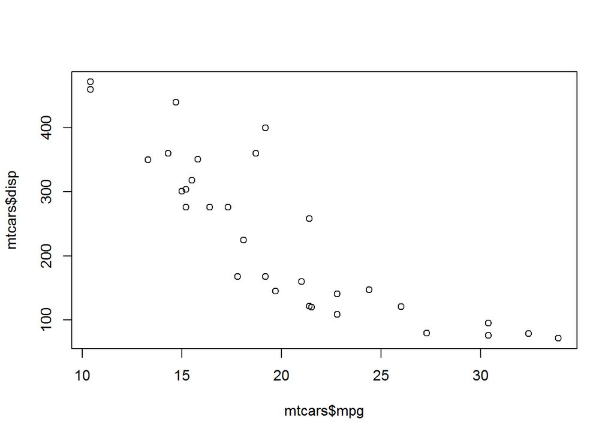

```r
plot(mtcars$mpg, mtcars$disp)
```

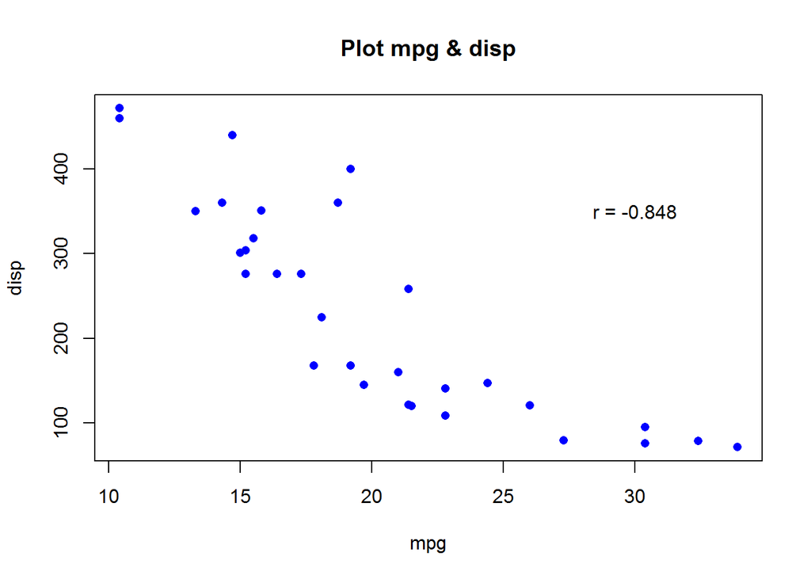

```r
plot(mtcars$mpg, mtcars$disp,
     xlab = "mpg", ylab = "disp",
     main = "Plot mpg & disp",
     pch = 16,
     col = "blue")
text(x = 30, y = 350,
     paste("r =", round(cor(mtcars$mpg, mtcars$disp),3)))
```

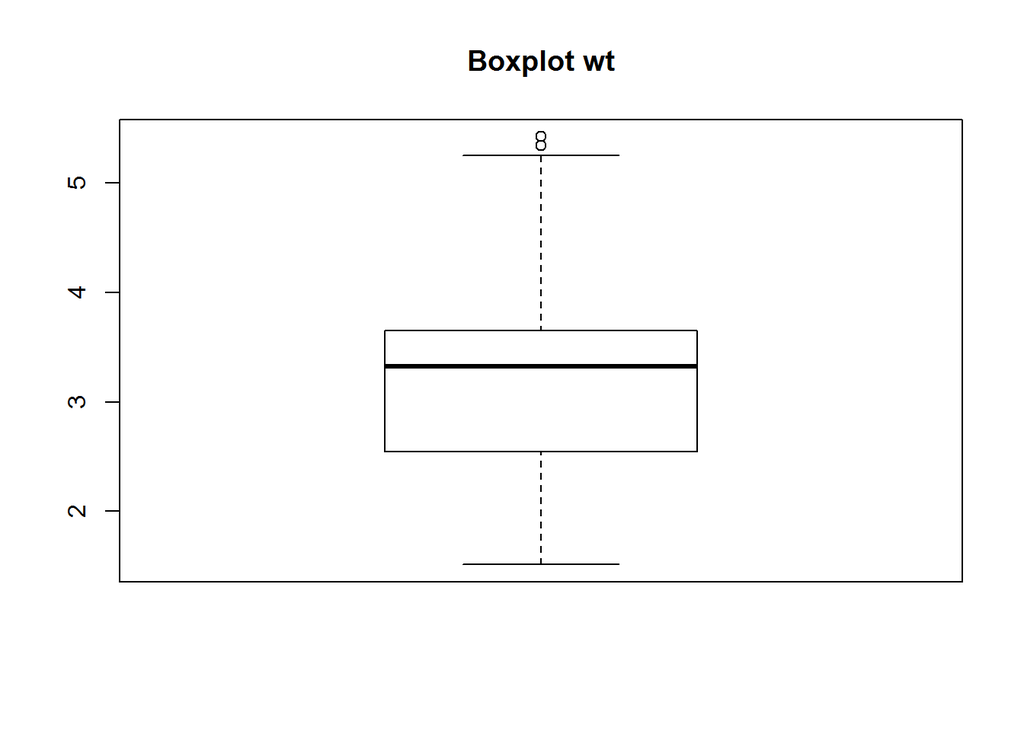

```r
boxplot(mtcars$wt, main = "Boxplot wt")
```

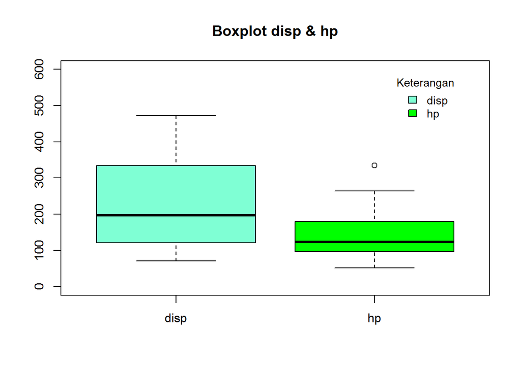

```r
boxplot(mtcars[,c("disp","hp")],
        main = "Boxplot disp & hp",
        col = c("aquamarine", "green"),
        ylim = c(0,600))
legend(x = 2.1, y = 590,
       legend = c("disp","hp"),
       fill = c("aquamarine", "green"),
       border = "black",
       box.lty = 0,
       title = "Keterangan",
       cex = 0.9)
```

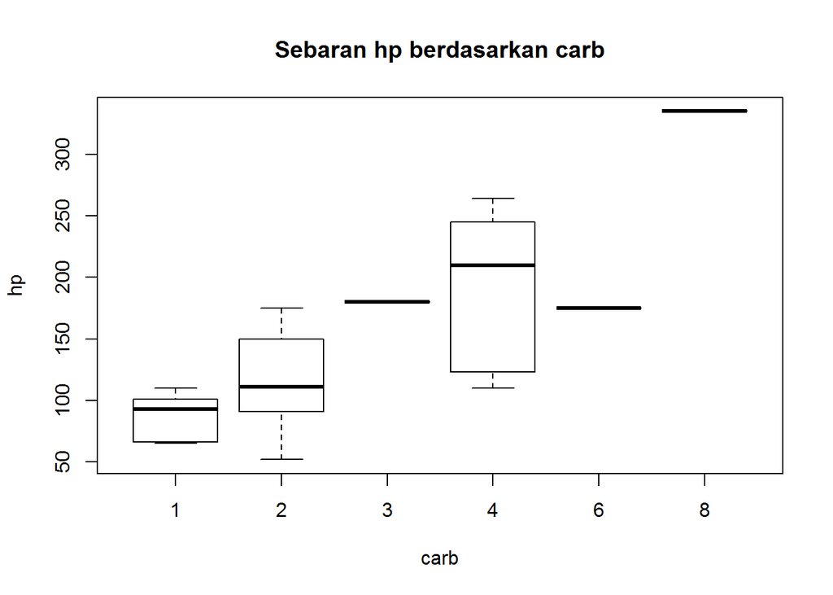

```r
boxplot(hp~carb, data = mtcars,
        xlab = "carb",
        ylab = "hp",
        main = "Sebaran hp berdasarkan carb")
```

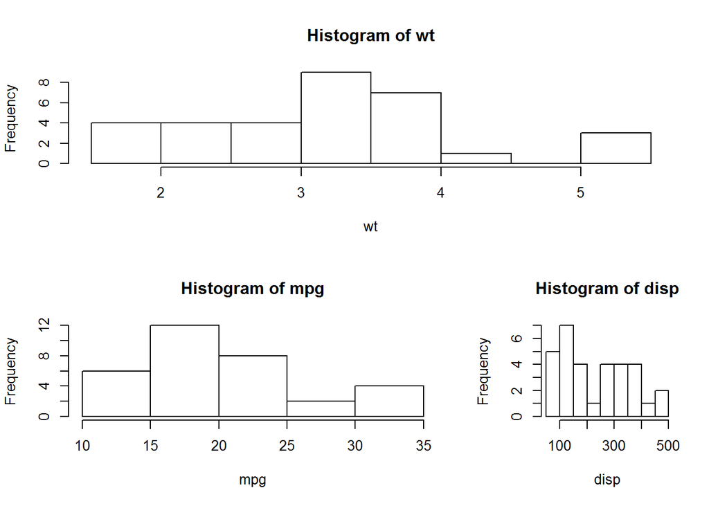

```r
# membuat beberapa plot dalam satu bingkai
attach(mtcars) # menguraikan variabel
layout(matrix(c(1,1,2,3), 2, 2, byrow = TRUE),
       widths=c(2,1))
hist(wt)
hist(mpg)
hist(disp)
```

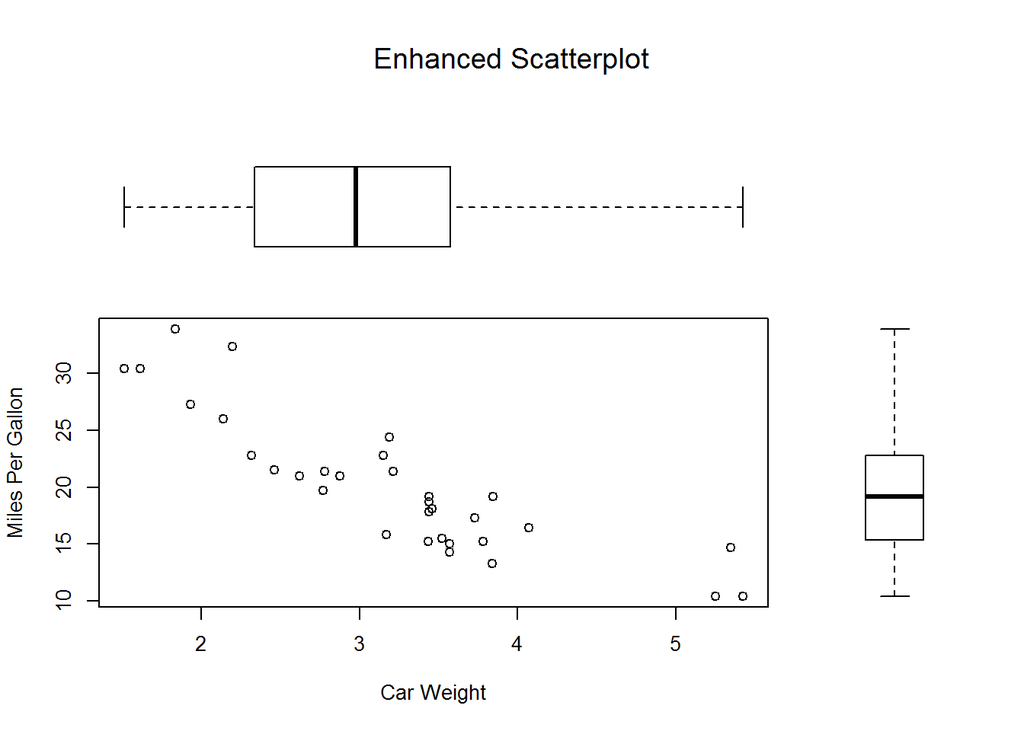

```r
detach(mtcars) # kebalikan dari attach

par(fig=c(0,0.8,0,0.7))
plot(mtcars$wt, mtcars$mpg, xlab="Car Weight",
     ylab="Miles Per Gallon")
par(fig=c(0,0.8,0.4,1),new=TRUE)
boxplot(mtcars$mpg, horizontal = TRUE, axes=FALSE)
par(fig=c(0.7,1,0,0.7),new=TRUE)
boxplot(mtcars$mpg, axes=FALSE)
mtext("Enhanced Scatterplot", side=3, outer=TRUE, line=-3, cex = 1.2)
```

```r
layout(1) # mengembalikan pengaturan default jumlah baris dan kolom layout plot
```

## 8. Pustaka (Packages) R

### 8.1. Menginstall Pustaka

Ada banyak pustaka yang dapat diunduh secara gratis di CRAN atau Github. Hanya saja, di sini kita akan mencoba 3 pustaka.

```r
install.packages("psych")
```

```
## Error in contrib.url(repos, "source"): trying to use CRAN without setting a mirror
```

```r
install.packages("summarytools")
```

```
## Error in contrib.url(repos, "source"): trying to use CRAN without setting a mirror
```

```r
install.packages("ggplot2")
```

```
## Error in contrib.url(repos, "source"): trying to use CRAN without setting a mirror
```

### 8.2. Menggunakan Pustaka

```r
library(psych)
library(summarytools)
library(ggplot2)
```

Data yang digunakan adalah data internal yaitu data iris

```r
# Memanggil data iris
data(iris)
str(iris) # struktur data iris
```

```
## 'data.frame':    150 obs. of  5 variables:
##  $ Sepal.Length: num  5.1 4.9 4.7 4.6 5 5.4 4.6 5 4.4 4.9 ...
##  $ Sepal.Width : num  3.5 3 3.2 3.1 3.6 3.9 3.4 3.4 2.9 3.1 ...
##  $ Petal.Length: num  1.4 1.4 1.3 1.5 1.4 1.7 1.4 1.5 1.4 1.5 ...
##  $ Petal.Width : num  0.2 0.2 0.2 0.2 0.2 0.4 0.3 0.2 0.2 0.1 ...
##  $ Species     : Factor w/ 3 levels "setosa","versicolor",..: 1 1 1 1 1 1 1 1 1 1 ...
```

```r
head(iris)
```

```
##   Sepal.Length Sepal.Width Petal.Length Petal.Width Species
## 1          5.1         3.5          1.4         0.2  setosa
## 2          4.9         3.0          1.4         0.2  setosa
## 3          4.7         3.2          1.3         0.2  setosa
## 4          4.6         3.1          1.5         0.2  setosa
## 5          5.0         3.6          1.4         0.2  setosa
## 6          5.4         3.9          1.7         0.4  setosa
```

#### 8.2.2. Menggunakan Pustaka

```r
# pustaka psych
citation("psych") # cara mengutip pustaka psych
```

```
##
##
##   Revelle, W. (2018) psych: Procedures for Personality and
##   Psychological Research, Northwestern University, Evanston,
##   Illinois, USA, https://CRAN.R-project.org/package=psych Version
##   = 1.8.12.
##
## A BibTeX entry for LaTeX users is
##
##   @Manual{,
##     title = {psych: Procedures for Psychological, Psychometric, and Personality Research},
##     author = {William Revelle},
##     organization = { Northwestern University},
##     address = { Evanston, Illinois},
##     year = {2018},
##     note = {R package version 1.8.12},
##     url = {https://CRAN.R-project.org/package=psych},
##   }
```

```r
describe(iris)
```

```
##              vars   n mean   sd median trimmed  mad min max range  skew
## Sepal.Length    1 150 5.84 0.83   5.80    5.81 1.04 4.3 7.9   3.6  0.31
## Sepal.Width     2 150 3.06 0.44   3.00    3.04 0.44 2.0 4.4   2.4  0.31
## Petal.Length    3 150 3.76 1.77   4.35    3.76 1.85 1.0 6.9   5.9 -0.27
## Petal.Width     4 150 1.20 0.76   1.30    1.18 1.04 0.1 2.5   2.4 -0.10
## Species*        5 150 2.00 0.82   2.00    2.00 1.48 1.0 3.0   2.0  0.00
##              kurtosis   se
## Sepal.Length    -0.61 0.07
## Sepal.Width      0.14 0.04
## Petal.Length    -1.42 0.14
## Petal.Width     -1.36 0.06
## Species*        -1.52 0.07
```

```r
describeBy(iris, group = iris$Species)
```

```
##
##  Descriptive statistics by group
## group: setosa
##              vars  n mean   sd median trimmed  mad min max range skew
## Sepal.Length    1 50 5.01 0.35    5.0    5.00 0.30 4.3 5.8   1.5 0.11
## Sepal.Width     2 50 3.43 0.38    3.4    3.42 0.37 2.3 4.4   2.1 0.04
## Petal.Length    3 50 1.46 0.17    1.5    1.46 0.15 1.0 1.9   0.9 0.10
## Petal.Width     4 50 0.25 0.11    0.2    0.24 0.00 0.1 0.6   0.5 1.18
## Species*        5 50 1.00 0.00    1.0    1.00 0.00 1.0 1.0   0.0  NaN
##              kurtosis   se
## Sepal.Length    -0.45 0.05
## Sepal.Width      0.60 0.05
## Petal.Length     0.65 0.02
## Petal.Width      1.26 0.01
## Species*          NaN 0.00
## --------------------------------------------------------
## group: versicolor
##              vars  n mean   sd median trimmed  mad min max range  skew
## Sepal.Length    1 50 5.94 0.52   5.90    5.94 0.52 4.9 7.0   2.1  0.10
## Sepal.Width     2 50 2.77 0.31   2.80    2.78 0.30 2.0 3.4   1.4 -0.34
## Petal.Length    3 50 4.26 0.47   4.35    4.29 0.52 3.0 5.1   2.1 -0.57
## Petal.Width     4 50 1.33 0.20   1.30    1.32 0.22 1.0 1.8   0.8 -0.03
## Species*        5 50 2.00 0.00   2.00    2.00 0.00 2.0 2.0   0.0   NaN
##              kurtosis   se
## Sepal.Length    -0.69 0.07
## Sepal.Width     -0.55 0.04
## Petal.Length    -0.19 0.07
## Petal.Width     -0.59 0.03
## Species*          NaN 0.00
## --------------------------------------------------------
## group: virginica
##              vars  n mean   sd median trimmed  mad min max range  skew
## Sepal.Length    1 50 6.59 0.64   6.50    6.57 0.59 4.9 7.9   3.0  0.11
## Sepal.Width     2 50 2.97 0.32   3.00    2.96 0.30 2.2 3.8   1.6  0.34
## Petal.Length    3 50 5.55 0.55   5.55    5.51 0.67 4.5 6.9   2.4  0.52
## Petal.Width     4 50 2.03 0.27   2.00    2.03 0.30 1.4 2.5   1.1 -0.12
## Species*        5 50 3.00 0.00   3.00    3.00 0.00 3.0 3.0   0.0   NaN
##              kurtosis   se
## Sepal.Length    -0.20 0.09
## Sepal.Width      0.38 0.05
## Petal.Length    -0.37 0.08
## Petal.Width     -0.75 0.04
## Species*          NaN 0.00
```

```r
# pustaka summarytools
citation("summarytools")
```

```
##
##
##   Dominic Comtois (2019). summarytools: Tools to Quickly and
##   Neatly Summarize Data. R package version 0.9.3.
##   https://CRAN.R-project.org/package=summarytools
##
## A BibTeX entry for LaTeX users is
##
##   @Manual{,
##     title = {summarytools: Tools to Quickly and Neatly Summarize Data},
##     author = {Dominic Comtois},
##     year = {2019},
##     note = {R package version 0.9.3},
##     url = {https://CRAN.R-project.org/package=summarytools},
##   }
```

```r
view(dfSummary(iris))
```

```
## Switching method to 'browser'
```

```
## Output file written: C:\Users\aa\AppData\Local\Temp\RtmpK2jxa6\file3ba457f93676.html
```

```r
# pustaka ggplot2
library(ggplot2)
head(iris)
```

```
##   Sepal.Length Sepal.Width Petal.Length Petal.Width Species
## 1          5.1         3.5          1.4         0.2  setosa
## 2          4.9         3.0          1.4         0.2  setosa
## 3          4.7         3.2          1.3         0.2  setosa
## 4          4.6         3.1          1.5         0.2  setosa
## 5          5.0         3.6          1.4         0.2  setosa
## 6          5.4         3.9          1.7         0.4  setosa
```

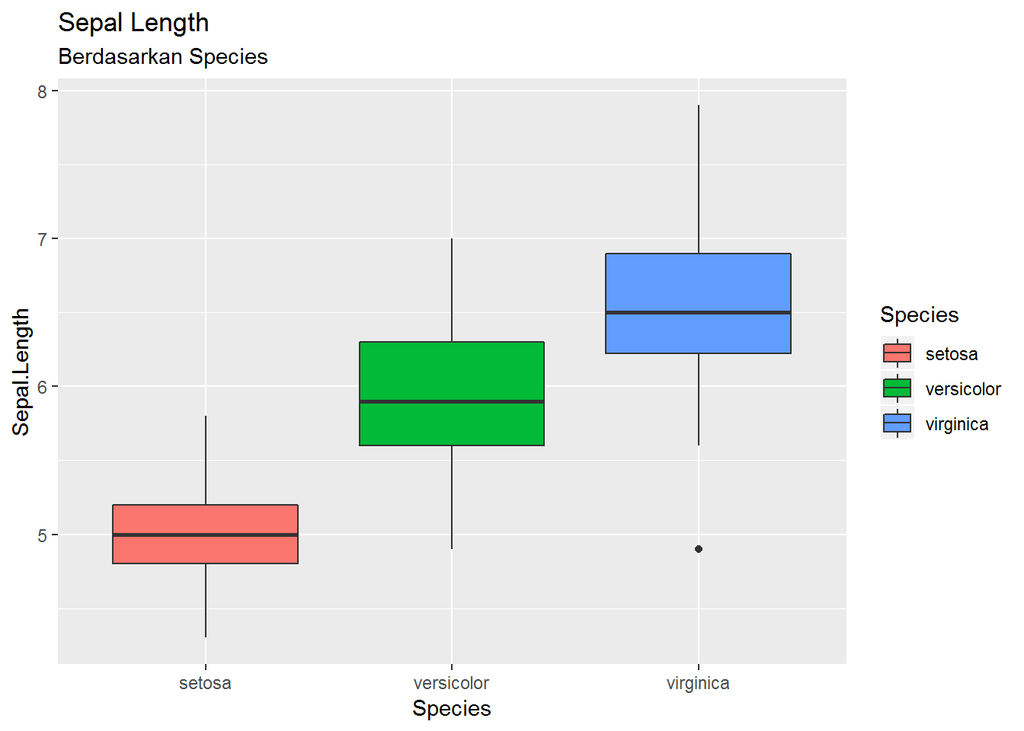

```r
ggplot(iris, aes(x = Species, y = Sepal.Length, fill = Species)) +
  geom_boxplot() +
  labs(title = "Sepal Length",
       subtitle = "Berdasarkan Species")
```